# R Notebook

### Library

```r
library(forecast)
```

```r
library(graphics)
library(TTR)
library(TSA)
library(dplyr)
library(forecast)
library(lmtest)
library(orcutt)
library(HoRM)
library(corrplot)
library(dLagM)
library(dynlm)
library(MLmetrics)
library(ggplot2)
library(tsibble)
library(tseries)
library(MASS)
library(aTSA)
```

# Input data

```r
library(readxl)
dt1 <- read_excel("databekasi.xlsx")
View(dt1)
```

### Ubah data menjadi time series

```r
dt1.ts <- ts(dt1$suhu)
```

### Membagi data menjadi data latih (80%) dan data uji (20%) dan jadikan time series

```r
dt1.latih <- dt1[1:115,2]
dt1.uji <- dt1[116:144,2]
dt1.latih.ts <- ts(dt1.latih, frequency = 12)
dt1.uji.ts <- ts(dt1.uji, frequency = 12)
```

# Eksplorasi data

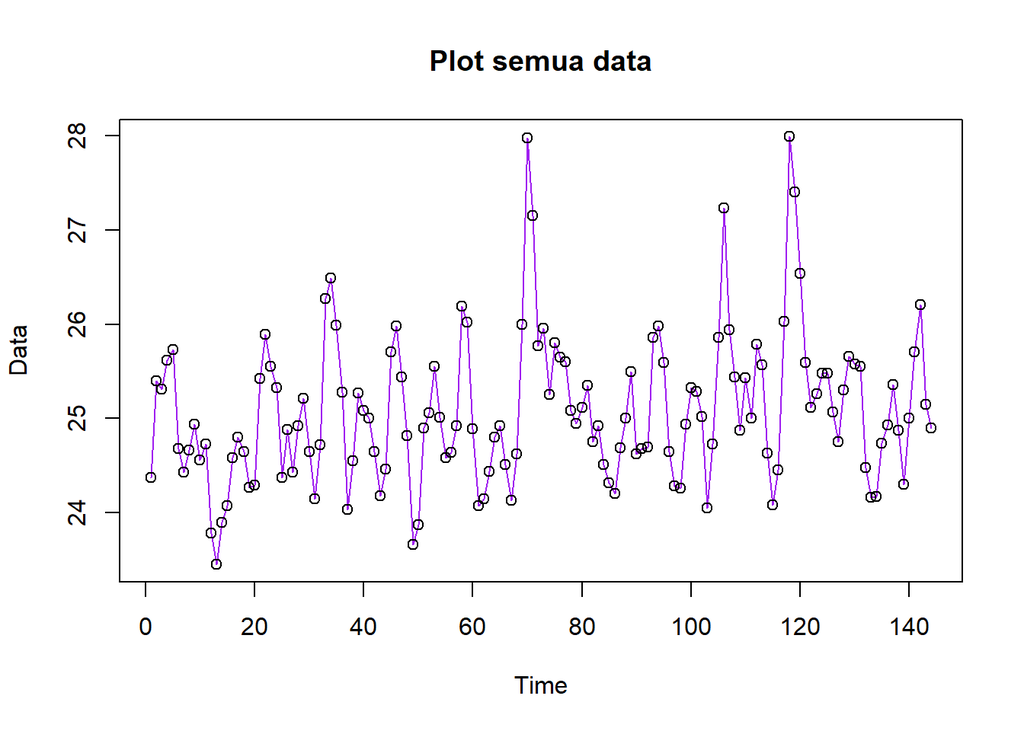

```r
# data full
ts.plot(dt1.ts, col="purple",main="Plot semua data", type="o",xlab="Time",ylab="Data")
points(dt1.ts)
```

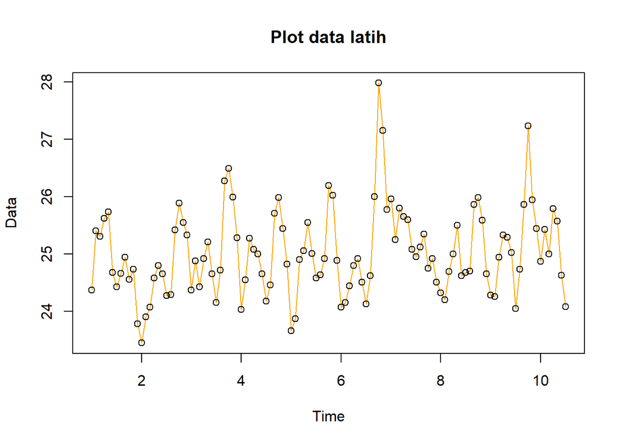

```r
# data latih
ts.plot(dt1.latih.ts, col="orange",main="Plot data latih", type="o",xlab="Time",ylab="Data")
points(dt1.latih.ts)
```

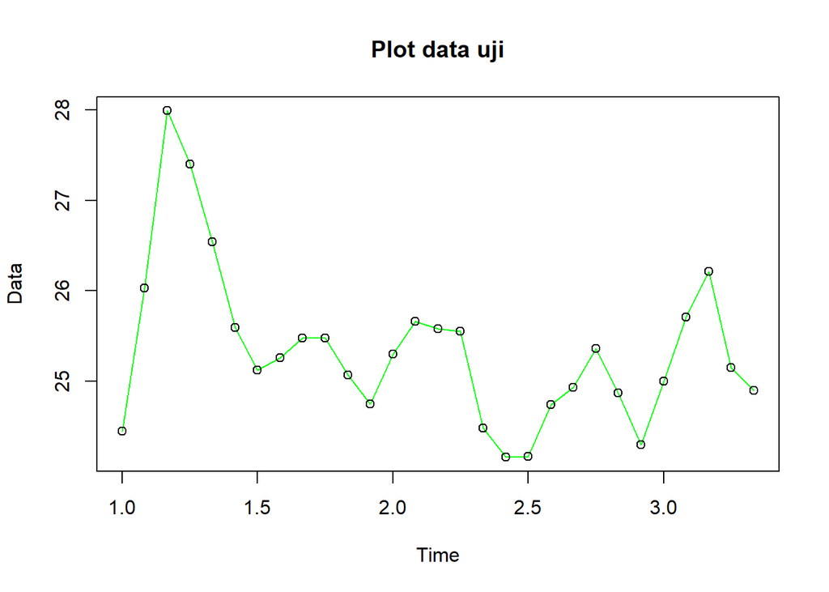

```r
# data uji
ts.plot(dt1.uji.ts, col="green",main="Plot data uji", type="o",xlab="Time",ylab="Data")
points(dt1.uji.ts)
```

dapat dilihat bahwwa data deret waktu pada suhu bekasi membentuk pola aditif musiman tanpa trend

# CEK Stasioner

### Plot acf

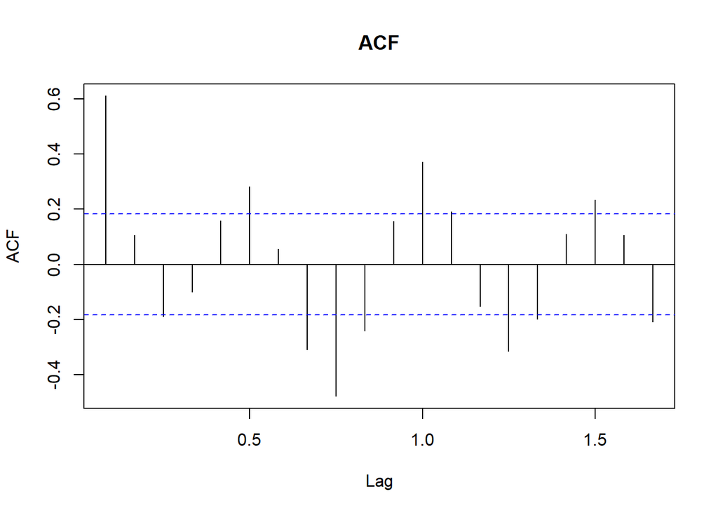

```r
acf(dt1.latih.ts, main="ACF", lag.max=20)
```

Berdasarkan plot ACF, terlihat bahwa plot ACF pada data tersebut cenderung *tails off* dan membentuk gelombang sinus. menandakan bahwa data tersebut stasioner dalam rataan

### Uji ADF

```r
tseries::adf.test(dt1.latih.ts)
```

```
##
##  Augmented Dickey-Fuller Test
##
## data:  dt1.latih.ts
## Dickey-Fuller = -3.565, Lag order = 4, p-value = 0.0395
## alternative hypothesis: stationary
```

$H_0$ : Data tidak stasioner dalam rataan

$H_1$ : Data stasioner dalam rataan

Berdasarkan uji ADF tersebut, didapat *p-value* sebesar 0.0395 yang lebih kecil dari taraf nyata 5% sehingga tolak $H_0$ dan menandakan bahwa data stasioner dalam rataan. Hal ini sesuai dengan hasil eksplorasi menggunakan plot time series dan plot ACF.

### Plot Box-Cox

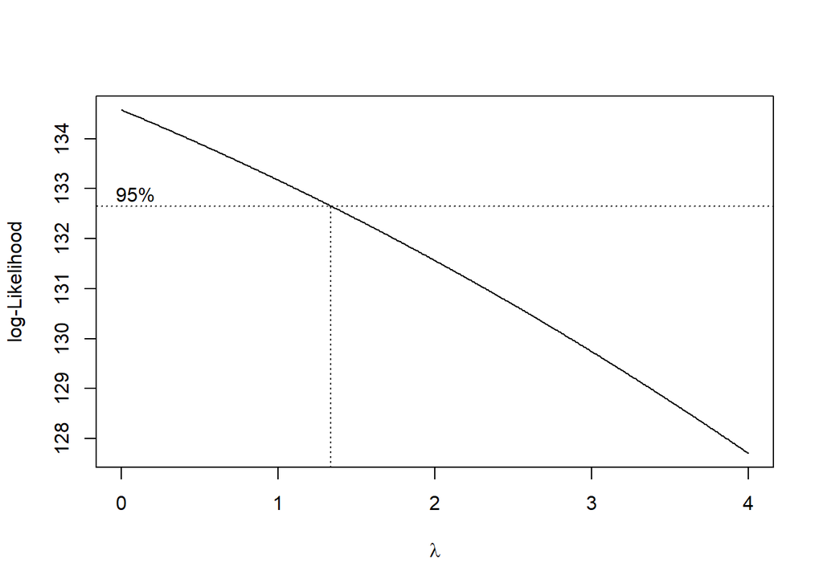

```r
index <- seq(1:115)
bc = boxcox(dt1.latih.ts~index, lambda = seq(0,4,by=0.01))
```

```r
#Nilai Rounded Lambda
lambda <- bc$x[which.max(bc$y)]
lambda
```

```
## [1] 0
```

```r
#SK
bc$x[bc$y > max(bc$y) - 1/2 * qchisq(.95,1)]
```

```
##   [1] 0.00 0.01 0.02 0.03 0.04 0.05 0.06 0.07 0.08 0.09 0.10 0.11 0.12 0.13 0.14
##  [16] 0.15 0.16 0.17 0.18 0.19 0.20 0.21 0.22 0.23 0.24 0.25 0.26 0.27 0.28 0.29
##  [31] 0.30 0.31 0.32 0.33 0.34 0.35 0.36 0.37 0.38 0.39 0.40 0.41 0.42 0.43 0.44
##  [46] 0.45 0.46 0.47 0.48 0.49 0.50 0.51 0.52 0.53 0.54 0.55 0.56 0.57 0.58 0.59
##  [61] 0.60 0.61 0.62 0.63 0.64 0.65 0.66 0.67 0.68 0.69 0.70 0.71 0.72 0.73 0.74
##  [76] 0.75 0.76 0.77 0.78 0.79 0.80 0.81 0.82 0.83 0.84 0.85 0.86 0.87 0.88 0.89
##  [91] 0.90 0.91 0.92 0.93 0.94 0.95 0.96 0.97 0.98 0.99 1.00 1.01 1.02 1.03 1.04
## [106] 1.05 1.06 1.07 1.08 1.09 1.10 1.11 1.12 1.13 1.14 1.15 1.16 1.17 1.18 1.19
## [121] 1.20 1.21 1.22 1.23 1.24 1.25 1.26 1.27 1.28 1.29 1.30 1.31 1.32 1.33
```

Gambar di atas menunjukkan nilai *rounded value* ($\lambda$) optimum sebesar **0** dan pada selang kepercayaan 95% nilai memiliki batas bawah **0.00 dan batas atas 1.33**. Selang tersebut memuat nilai satu sehingga dapat dikatakan bahwa data bangkitan stasioner dalam ragam.

# Identifikasi model

### Plot ACF dan PACF

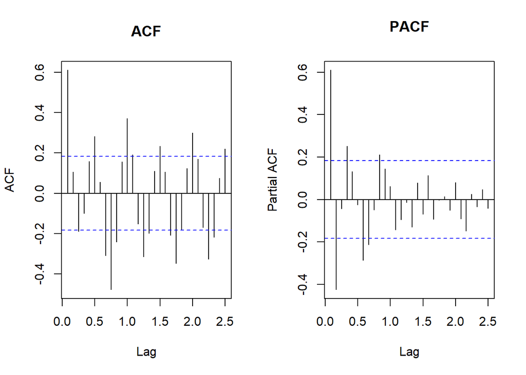

```r
par(mfrow = c(1,2))
acf(dt1.latih.ts, main="ACF", lag.max=30) #ARIMA(0,0,1)
pacf(dt1.latih.ts, main="PACF", lag.max=30) #ARIMA(2,0,0)
```

Berdasarkan plot tersebut, terlihat bahwa plot ACF cenderung cuts off pada lag ke 1, sehingga jika plot PACF dianggap tails of, maka model tentatifnya adalah ARIMA(0,0,1).

Berdasarkan plot tersebut, terlihat bahwa plot PACF cenderung cuts off pada lag ke 2, sehingga jika plot ACF dianggap tails of, maka model tentatifnya adalah ARIMA(2,0,0).

### Plot EACF

```r
eacf(dt1.latih.ts)
```

```
## AR/MA
##   0 1 2 3 4 5 6 7 8 9 10 11 12 13
## 0 x o x o o x o x x x o  x  o  o
## 1 x x x o o x o x x x o  x  o  o
## 2 o x o o o o o o o o o  o  o  o
## 3 o x o o o o o o o o o  o  o  o
## 4 x x o x o o o o o o o  o  o  o
## 5 x o x o o o o o o o o  o  o  o
## 6 o x x x o o o o o o o  o  o  o
## 7 x x x o o x o o o o o  o  o  o
```

identifikasi model menggunakan plot EACF dilakukan dengan melihat ujung segitiga pada pola segitiga nol. Dalam hal ini model tentatif yang terbentuk adalah ARIMA(2,0,1), dan ARIMA (2,0,2)

# Pendugaan Parameter

### ARIMA (0,0,1)

```r
model1=Arima(dt1.latih.ts, order=c(0,0,1),method="ML")
summary(model1) #AIC=207.77
```

```
## Series: dt1.latih.ts
## ARIMA(0,0,1) with non-zero mean
##
## Coefficients:
##          ma1     mean
##       0.6204  25.0113
## s.e.  0.0556   0.0874
##
## sigma^2 = 0.343:  log likelihood = -100.89
## AIC=207.77   AICc=207.99   BIC=216.01
##
## Training set error measures:
##                       ME      RMSE       MAE         MPE     MAPE      MASE
## Training set 0.002800733 0.5805552 0.4473272 -0.04862493 1.778439 0.7278785
##                   ACF1
## Training set 0.2154352
```

```r
lmtest::coeftest(model1) #signifikan
```

```
##
## z test of coefficients:
##
##            Estimate Std. Error z value  Pr(>|z|)
## ma1        0.620434   0.055617  11.155 < 2.2e-16 ***
## intercept 25.011251   0.087439 286.042 < 2.2e-16 ***
## ---
## Signif. codes:  0 '***' 0.001 '**' 0.01 '*' 0.05 '.' 0.1 ' ' 1
```

### ARIMA (2,0,0)

```r
model2=Arima(dt1.latih.ts, order=c(2,0,0),method="ML")
summary(model2) #AIC=187.1
```

```
## Series: dt1.latih.ts
## ARIMA(2,0,0) with non-zero mean
##
## Coefficients:
##          ar1      ar2     mean
##       0.8984  -0.4488  25.0082
## s.e.  0.0842   0.0838   0.0890
##
## sigma^2 = 0.283:  log likelihood = -89.55
## AIC=187.1   AICc=187.47   BIC=198.08
##
## Training set error measures:
##                       ME      RMSE       MAE        MPE     MAPE      MASE
## Training set 0.003413663 0.5250303 0.4003124 -0.0294696 1.592608 0.6513771
##                     ACF1
## Training set -0.02178598
```

```r
lmtest::coeftest(model2) #signifikan
```

```
##
## z test of coefficients:
##
##            Estimate Std. Error  z value  Pr(>|z|)
## ar1        0.898431   0.084177  10.6731 < 2.2e-16 ***
## ar2       -0.448806   0.083828  -5.3539 8.609e-08 ***
## intercept 25.008248   0.089016 280.9395 < 2.2e-16 ***
## ---
## Signif. codes:  0 '***' 0.001 '**' 0.01 '*' 0.05 '.' 0.1 ' ' 1
```

### ARIMA (2,0,1)

```r
model3=Arima(dt1.latih.ts, order=c(2,0,1),method="ML")
summary(model3) #AIC=189.59
```

```
## Series: dt1.latih.ts
## ARIMA(2,0,1) with non-zero mean
##
## Coefficients:
##          ar1      ar2      ma1     mean
##       0.9260  -0.4659  -0.0344  25.0084
## s.e.  0.1394   0.1071   0.1413   0.0876
##
## sigma^2 = 0.2854:  log likelihood = -89.52
## AIC=189.04   AICc=189.59   BIC=202.77
##
## Training set error measures:
##                       ME      RMSE       MAE         MPE     MAPE      MASE
## Training set 0.003343597 0.5248939 0.4001272 -0.02973172 1.591877 0.6510759
##                     ACF1
## Training set -0.01111988
```

```r
lmtest::coeftest(model3) #tidak signifikan
```

```
##
## z test of coefficients:
##
##            Estimate Std. Error  z value  Pr(>|z|)
## ar1        0.926047   0.139440   6.6412 3.112e-11 ***
## ar2       -0.465932   0.107078  -4.3513 1.353e-05 ***
## ma1       -0.034379   0.141272  -0.2434    0.8077
## intercept 25.008429   0.087642 285.3475 < 2.2e-16 ***
## ---
## Signif. codes:  0 '***' 0.001 '**' 0.01 '*' 0.05 '.' 0.1 ' ' 1
```

### ARIMA (2,0,2)

```r
model4 <- Arima(dt1.latih.ts, order=c(2,0,2),method="ML")
summary(model4) #AIC=412.44
```

```
## Series: dt1.latih.ts
## ARIMA(2,0,2) with non-zero mean
##
## Coefficients:
##          ar1      ar2      ma1     ma2     mean
##       0.8355  -0.5973  -0.0075  0.3577  25.0104
## s.e.  0.1401   0.1313   0.1793  0.1238   0.0844
##
## sigma^2 = 0.2724:  log likelihood = -86.43
## AIC=184.85   AICc=185.63   BIC=201.32
##
## Training set error measures:
##                       ME      RMSE       MAE         MPE     MAPE      MASE
## Training set 0.002123472 0.5104186 0.3894163 -0.03244071 1.549673 0.6336473
##                    ACF1
## Training set 0.04321785
```

```r
lmtest::coeftest(model4) #tidak signifikan
```

```
##
## z test of coefficients:
##
##             Estimate Std. Error  z value  Pr(>|z|)
## ar1        0.8355306  0.1400820   5.9646 2.453e-09 ***
## ar2       -0.5972519  0.1313134  -4.5483 5.408e-06 ***
## ma1       -0.0075442  0.1793408  -0.0421  0.966446
## ma2        0.3576848  0.1237767   2.8898  0.003855 **
## intercept 25.0104091  0.0843849 296.3849 < 2.2e-16 ***
## ---
## Signif. codes:  0 '***' 0.001 '**' 0.01 '*' 0.05 '.' 0.1 ' ' 1
```

Penduga terbaik ialah aic terkecil dan parameter signifikan yang terdapat di ARIMA(2,0,0)

# Analisis Sisaan

### Eksplorasi

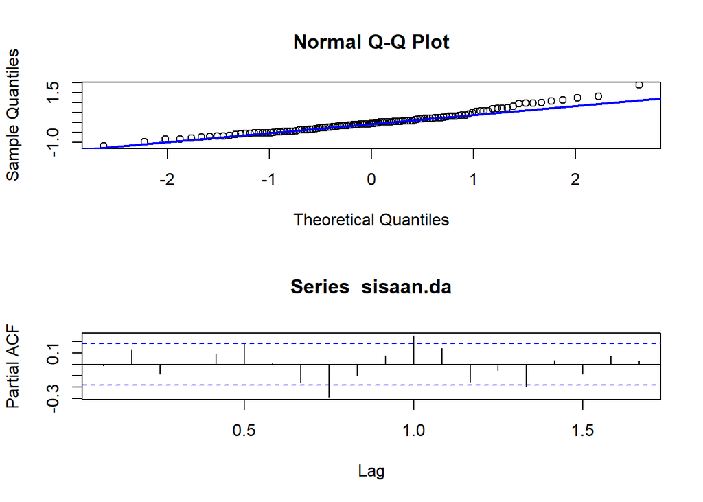

```r
#Eksplorasi
sisaan.da <- model3$residuals
par(mfrow=c(2,1))
qqnorm(sisaan.da)
qqline(sisaan.da, col = "blue", lwd = 2)
pacf(sisaan.da)
```

```r
par(mfrow = c(1,1))
```

### Uji Formal

```r
#1) Sisaan Menyebar Normal
ks.test(sisaan.da,"pnorm")
```

```
##
##  Asymptotic one-sample Kolmogorov-Smirnov test
##
## data:  sisaan.da
## D = 0.1903, p-value = 0.0004829
## alternative hypothesis: two-sided
```

$H_0$ : Sisaan menyebar normal

$H_1$ : Sisaan tidak menyebar normal

```r
#2) Sisaan saling bebas/tidak ada autokorelasi
Box.test(sisaan.da, type = "Ljung")
```

```
##
##  Box-Ljung test
##
## data:  sisaan.da
## X-squared = 0.014594, df = 1, p-value = 0.9038
```

$H_0$ : Sisaan saling bebas

$H_1$ : Sisaan tidak tidak saling bebas

```r
#3) Sisaan homogen
Box.test((sisaan.da)^2, type = "Ljung")
```

```
##
##  Box-Ljung test
##
## data:  (sisaan.da)^2
## X-squared = 0.01187, df = 1, p-value = 0.9132
```

$H_0$ : Ragam sisaan homogen

$H_1$ : Ragam sisaan tidak homogen

```r
#4) Nilai tengah sisaan sama dengan nol
t.test(sisaan.da, mu = 0, conf.level = 0.95)  #tak tolak h0 > nilai tengah sisaan sama dengan 0
```

```
##
##  One Sample t-test
##
## data:  sisaan.da
## t = 0.068015, df = 114, p-value = 0.9459
## alternative hypothesis: true mean is not equal to 0
## 95 percent confidence interval:
##  -0.09404163  0.10072883
## sample estimates:
##   mean of x
## 0.003343597
```

$H_0$ : nilai tengah sisaan sama dengan 0

$H_1$ : nilai tengah sisaan tidak sama dengan 0

# Overfitting

### ARIMA(3,0,0)

```r
model5=Arima(dt1.latih.ts, order=c(3,0,0),method="ML")
summary(model5) #AIC=188.98
```

```
## Series: dt1.latih.ts
## ARIMA(3,0,0) with non-zero mean
##
## Coefficients:
##          ar1      ar2      ar3     mean
##       0.8834  -0.4183  -0.0336  25.0086
## s.e.  0.0941   0.1197   0.0942   0.0862
##
## sigma^2 = 0.2853:  log likelihood = -89.49
## AIC=188.98   AICc=189.53   BIC=202.7
##
## Training set error measures:
##                       ME      RMSE       MAE         MPE     MAPE      MASE
## Training set 0.003275801 0.5247331 0.3997803 -0.02998139 1.590503 0.6505115
##                     ACF1
## Training set 0.001645513
```

```r
lmtest::coeftest(model5) #Tidak signifikan
```

```
##
## z test of coefficients:
##
##            Estimate Std. Error  z value  Pr(>|z|)
## ar1        0.883391   0.094076   9.3902 < 2.2e-16 ***
## ar2       -0.418304   0.119698  -3.4947 0.0004747 ***
## ar3       -0.033611   0.094218  -0.3567 0.7212907
## intercept 25.008602   0.086202 290.1160 < 2.2e-16 ***
## ---
## Signif. codes:  0 '***' 0.001 '**' 0.01 '*' 0.05 '.' 0.1 ' ' 1
```

```r
model5=Arima(dt1.latih.ts, order=c(2,0,1),method="ML")
summary(model5) #AIC=189.04
```

```
## Series: dt1.latih.ts
## ARIMA(2,0,1) with non-zero mean
##
## Coefficients:
##          ar1      ar2      ma1     mean
##       0.9260  -0.4659  -0.0344  25.0084
## s.e.  0.1394   0.1071   0.1413   0.0876
##
## sigma^2 = 0.2854:  log likelihood = -89.52
## AIC=189.04   AICc=189.59   BIC=202.77
##
## Training set error measures:
##                       ME      RMSE       MAE         MPE     MAPE      MASE
## Training set 0.003343597 0.5248939 0.4001272 -0.02973172 1.591877 0.6510759
##                     ACF1
## Training set -0.01111988
```

```r
lmtest::coeftest(model5) #Tidak signifikan
```

```
##
## z test of coefficients:
##
##            Estimate Std. Error  z value  Pr(>|z|)
## ar1        0.926047   0.139440   6.6412 3.112e-11 ***
## ar2       -0.465932   0.107078  -4.3513 1.353e-05 ***
## ma1       -0.034379   0.141272  -0.2434    0.8077
## intercept 25.008429   0.087642 285.3475 < 2.2e-16 ***
## ---
## Signif. codes:  0 '***' 0.001 '**' 0.01 '*' 0.05 '.' 0.1 ' ' 1
```

berdasarkan hasil overfitting, model yang terbaik tetap model ARIMA(2,0,0)

# Peramalan

```r
#---FORECAST---#
ramalan <- forecast::forecast(model2, h = 29)
ramalan
```

```
##        Point Forecast    Lo 80    Hi 80    Lo 95    Hi 95
## Aug 10       24.34404 23.66224 25.02585 23.30131 25.38677
## Sep 10       24.82811 23.91155 25.74467 23.42635 26.22986
## Oct 10       25.14450 24.19593 26.09307 23.69379 26.59522
## Nov 10       25.21151 24.26133 26.16170 23.75833 26.66470
## Dec 10       25.12972 24.16625 26.09318 23.65622 26.60321
## Jan 11       25.02615 24.05544 25.99686 23.54157 26.51073
## Feb 11       24.96982 23.99848 25.94115 23.48429 26.45535
## Mar 11       24.96569 23.99410 25.93727 23.47978 26.45159
## Apr 11       24.98726 24.01503 25.95948 23.50037 26.47414
## May 11       25.00849 24.03602 25.98096 23.52123 26.49575
## Jun 11       25.01789 24.04541 25.99036 23.53061 26.50516
## Jul 11       25.01680 24.04430 25.98930 23.52949 26.50410
## Aug 11       25.01160 24.03908 25.98413 23.52426 26.49895
## Sep 11       25.00743 24.03489 25.97996 23.52007 26.49479
## Oct 11       25.00600 24.03347 25.97854 23.51864 26.49336
## Nov 11       25.00660 24.03407 25.97913 23.51924 26.49396
## Dec 11       25.00778 24.03524 25.98031 23.52041 26.49514
## Jan 12       25.00856 24.03603 25.98110 23.52120 26.49593
## Feb 12       25.00874 24.03621 25.98128 23.52138 26.49611
## Mar 12       25.00855 24.03602 25.98109 23.52119 26.49592
## Apr 12       25.00830 24.03576 25.98083 23.52093 26.49566
## May 12       25.00816 24.03562 25.98069 23.52079 26.49552
## Jun 12       25.00814 24.03561 25.98068 23.52078 26.49551
## Jul 12       25.00820 24.03566 25.98073 23.52083 26.49556
## Aug 12       25.00825 24.03571 25.98078 23.52088 26.49561
## Sep 12       25.00827 24.03574 25.98081 23.52091 26.49564
## Oct 12       25.00827 24.03573 25.98080 23.52090 26.49563
## Nov 12       25.00826 24.03572 25.98079 23.52089 26.49562
## Dec 12       25.00825 24.03571 25.98078 23.52088 26.49561
```

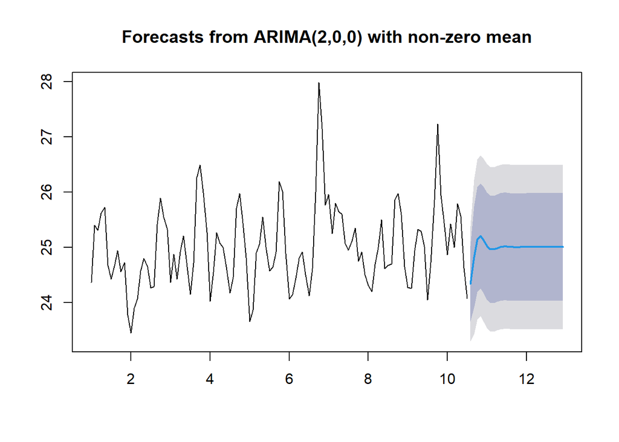

```r
data.ramalan <- ramalan$mean
plot(ramalan)
```

# AKURASI

```r
perbandingan <- matrix(data=c(head(dt1.uji.ts, n=29), data.ramalan),
                     nrow = 29, ncol = 2)
colnames(perbandingan) <- c("Aktual","Hasil Forecast")
perbandingan
```

```
##       Aktual Hasil Forecast
##  [1,]  24.45       24.34404
##  [2,]  26.03       24.82811
##  [3,]  27.99       25.14450
##  [4,]  27.40       25.21151
##  [5,]  26.54       25.12972
##  [6,]  25.59       25.02615
##  [7,]  25.12       24.96982
##  [8,]  25.26       24.96569
##  [9,]  25.48       24.98726
## [10,]  25.48       25.00849
## [11,]  25.07       25.01789
## [12,]  24.75       25.01680
## [13,]  25.30       25.01160
## [14,]  25.66       25.00743
## [15,]  25.58       25.00600
## [16,]  25.55       25.00660
## [17,]  24.48       25.00778
## [18,]  24.16       25.00856
## [19,]  24.17       25.00874
## [20,]  24.74       25.00855
## [21,]  24.93       25.00830
## [22,]  25.36       25.00816
## [23,]  24.87       25.00814
## [24,]  24.30       25.00820
## [25,]  25.00       25.00825
## [26,]  25.71       25.00827
## [27,]  26.21       25.00827
## [28,]  25.15       25.00826
## [29,]  24.90       25.00825
```

```r
accuracy(data.ramalan[1:29], head(dt1.uji.ts, n=29))
```

```
##                 ME      RMSE       MAE      MPE     MAPE     ACF1 Theil's U
## Test set 0.3600233 0.8871519 0.6215105 1.318693 2.391349 0.693442  1.242555
```